# HF Statistics 2

# 2장. 중심적 경향 파악하기

1장의 내용은, 단순히 숫자들의 열거로서의 이해하기 어려운 데이터를 시각화함으로써 쉽게 파악하고 의미도 부여할 수 있다는 것이었죠.

2장에서는 데이터를 바라보는 세 가지 대표적인 기준점 ’평균값 / 중앙값 / 최빈값’을 배우고 그 기준들을 통해 데이터의 경향성을 파악하는 연습을 해보겠습니다.

## 평균값, 중앙값, 최빈값

각각이 의미하바 바가 무엇인지, 또 언제 사용하는지 살펴봅시다.

먼저, 평균값입니다. 다들 잘 아시다시피, 각각의 값들을 더하고 값들의 개수로 나눈 값을 의미합니다. 평균값은 데이터가 비교적 좌우대칭이고 하나의 경향성을 나타낼 때에 사용합니다.

다음으로, 중앙값은 순서를 나열했을 때 중앙에 있는 값을 말합니다. 중앙값은 숫자의 개수에 따라 구하는 법이 다릅니다. 홀수일 때는 가운데 숫자를, 짝수일 때는 가운데 두 숫자를 더하고 절반으로 나눈 값을 사용합니다. 중앙값은 데이터가 이상치(outlier), 즉 극단적인 값을 포함할 때 사용합니다. 순서를 나타내는 값이기 때문에 극단적인 크기를 배제할 수 있는 것이죠.

마지막으로 최빈값은 가장 많이 나타난, 다시말해 도수(frequency)가 가장 높은 값을 말합니다. 최빈값은 범주적 데이터를 다룰 수 있으며, 복수의 데이터 그룹을 비교할 수 있어 그 값이 하나 이상일 수 있습니다. 그럴 때는 그룹당 한 개의 최빈값을 구해줍니다.

## 평균값과 중앙값의 비교

평균값과 중앙값을 통해 우리는 데이터가 왼쪽이나 오른쪽으로 치우친 정도(좌/우 편향성)을 알 수 있습니다.

두 가지 경우가 있겠죠. 평균값이 중앙값의 왼쪽에 있는 경우와 오른쪽에 있는 경우로 말이죠.

전자는 무엇을 의미할까요. 1) 중앙값이 오른쪽에 있다 = 높은 숫자들이 많이 있는데 2) 평균은 왼쪽에 있다 = 높은 숫자들을 상쇄하는 굉장히 낮은 숫자가 더러 있다.

후자는 그 반대겠죠. 1) 중앙값이 왼쪽에 있다 = 낮은 숫자들이 많이 있는데 2) 평균은 오른쪽에 있다 = 낮은 숫자들을 상쇄할 매우 높은 숫자가 몇 개 있다.

p.95

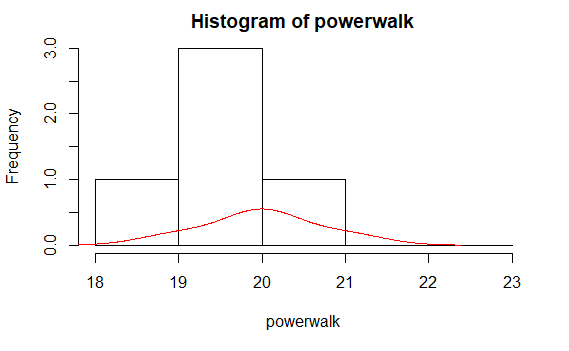

```r
powerwalk = c(19,20,20,20,21)
kungfu = c(19,19,19,20,20,20,20,20,20,21,21,21,145,147)
hist(powerwalk, breaks=c(18,19,20,21,22,23))
lines(density(powerwalk),col="red")
```

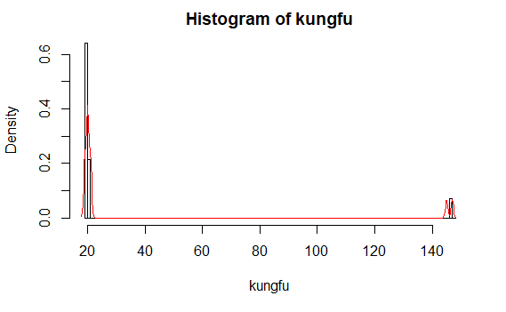

```r
hist(kungfu, breaks = c(19,20,21,22,145,146,147,148))
lines(density(kungfu), col="red")
```

```r
median(powerwalk)
```

```
[1] 20
```

```r
median(kungfu)
```

```
[1] 20
```

p.103

```r
x1 = c(1,1,1,1, 2,2,2,2,2,2, 3,3,3,3, 4,4,4,4, 5,5,5, 6,6, 7, 8)
x2 = c(1, 4, 6,6, 8,8,8, 9,9,9,9, 10,10,10,10, 11,11,11,11,11, 12,12,12,12,12)
hist(tapply(x1))
```

```
Error in tapply(x1) : argument "INDEX" is missing, with no default
```

p.107

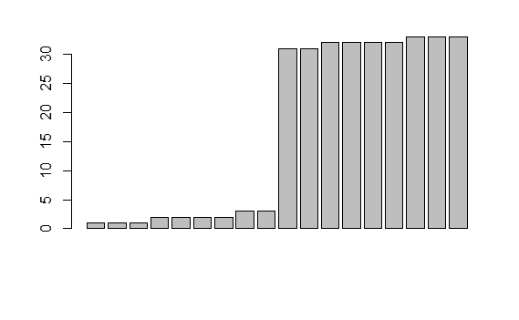

```r
x1=c(1,2,3,31,32,33)
y1=c(3,4,2,2,4,3)
swim = c(1,1,1, 2,2,2,2, 3,3, 31,31, 32,32,32,32, 33,33,33)
barplot(swim)
```

[figure not shown]

```r
hist(swim, breaks = c(0,34,by=35))
```

```r
matrix(c(1,2,3,4,5,6), ncol=2)
```

```
     [,1] [,2]
[1,]    1    4
[2,]    2    5
[3,]    3    6
```

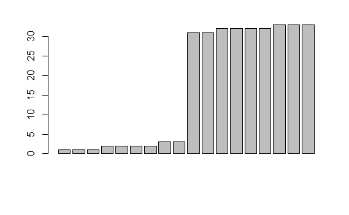

```r
barplot(swim)
```